# CS5801 Coursework Template Proforma

```r
step(model_lm)
```

```
Start:  AIC=6794.72
price ~ year + mileage + engine_size + avg_mpg + brand_group +
    automatic_transmission + fuel_group + drivetrain_group +
    damaged + first_owner + navigation_system + bluetooth + third_row_seating +
    heated_seats

                         Df  Sum of Sq        RSS    AIC
- heated_seats            1 2.9035e+05 5.9447e+09 6792.7
- damaged                 1 3.8819e+06 5.9482e+09 6793.0
- fuel_group              1 1.1646e+07 5.9560e+09 6793.5
- avg_mpg                 1 1.3003e+07 5.9574e+09 6793.6
<none>                                 5.9444e+09 6794.7
- third_row_seating       1 2.9338e+07 5.9737e+09 6794.7
- navigation_system       1 3.2301e+07 5.9767e+09 6794.9
- bluetooth               1 3.2972e+07 5.9773e+09 6795.0
- automatic_transmission  1 4.4395e+07 5.9888e+09 6795.8
- first_owner             1 1.0748e+08 6.0518e+09 6800.1
- year                    1 2.5290e+08 6.1973e+09 6809.8
- engine_size             1 2.7589e+08 6.2202e+09 6811.3
- drivetrain_group        2 5.7537e+08 6.5197e+09 6828.6
- mileage                 1 8.7676e+08 6.8211e+09 6849.1
- brand_group             2 1.0723e+10 1.6667e+10 7213.4

Step:  AIC=6792.74
price ~ year + mileage + engine_size + avg_mpg + brand_group +
    automatic_transmission + fuel_group + drivetrain_group +
    damaged + first_owner + navigation_system + bluetooth + third_row_seating

                         Df  Sum of Sq        RSS    AIC
- damaged                 1 3.9266e+06 5.9486e+09 6791.0
- fuel_group              1 1.1523e+07 5.9562e+09 6791.5
- avg_mpg                 1 1.3078e+07 5.9577e+09 6791.6
<none>                                 5.9447e+09 6792.7
- third_row_seating       1 2.9839e+07 5.9745e+09 6792.8
- bluetooth               1 3.3377e+07 5.9780e+09 6793.0
- navigation_system       1 3.7735e+07 5.9824e+09 6793.3
- automatic_transmission  1 4.4780e+07 5.9894e+09 6793.8
- first_owner             1 1.0764e+08 6.0523e+09 6798.1
- year                    1 2.5420e+08 6.1989e+09 6807.9
- engine_size             1 2.7810e+08 6.2227e+09 6809.5
```

[output cut: 95 more lines]

```
    navigation_system, data = mydf)

Coefficients:
                      (Intercept)                               year
                       -3.403e+05                          1.899e+02
                          mileage                        engine_size
                       -6.106e-02                          1.158e+03
             brand_groupLow_Price               brand_groupMid_Price
                       -2.176e+04                         -1.123e+04
          automatic_transmission1   drivetrain_groupFour-wheel Drive
                       -1.469e+03                          4.823e+02
drivetrain_groupFront-wheel Drive                       first_owner1
                       -2.831e+03                          1.235e+03
               navigation_system1
                        9.832e+02
```

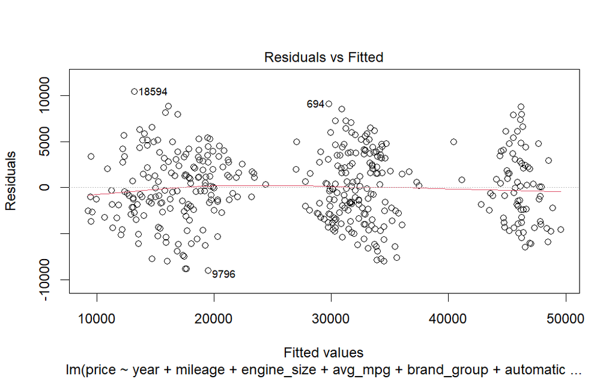

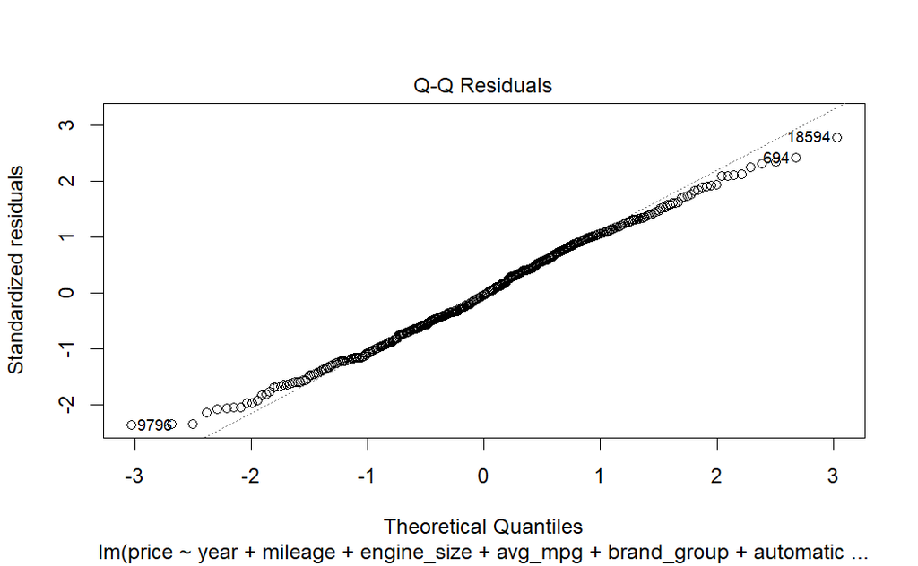

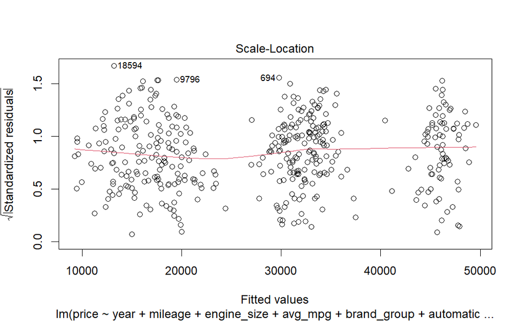

```r
plot(model_lm)
```

[figure not shown]

```r
NA
```

6. Summarising Model 2:

```r
model2 <-lm(formula = price ~ year + mileage + engine_size + brand_group +
    automatic_transmission + drivetrain_group + first_owner +
    navigation_system, data = mydf)
summary(model2)
```

```
Call:
lm(formula = price ~ year + mileage + engine_size + brand_group +
    automatic_transmission + drivetrain_group + first_owner +
    navigation_system, data = mydf)

Residuals:
    Min      1Q  Median      3Q     Max
-9204.9 -2870.2   -75.6  2902.2 10410.1

Coefficients:
                                    Estimate Std. Error t value Pr(>|t|)
(Intercept)                       -3.403e+05  7.658e+04  -4.444 1.14e-05 ***
year                               1.899e+02  3.804e+01   4.992 8.96e-07 ***
mileage                           -6.106e-02  7.946e-03  -7.684 1.21e-13 ***
engine_size                        1.158e+03  2.255e+02   5.134 4.44e-07 ***
brand_groupLow_Price              -2.176e+04  7.995e+02 -27.214  < 2e-16 ***
brand_groupMid_Price              -1.123e+04  5.762e+02 -19.481  < 2e-16 ***
automatic_transmission1           -1.469e+03  7.785e+02  -1.887  0.05985 .
drivetrain_groupFour-wheel Drive   4.823e+02  5.509e+02   0.876  0.38176
drivetrain_groupFront-wheel Drive -2.831e+03  6.442e+02  -4.395 1.42e-05 ***
first_owner1                       1.235e+03  4.452e+02   2.773  0.00582 **
navigation_system1                 9.832e+02  4.315e+02   2.278  0.02323 *
---
Signif. codes:  0 ‘***’ 0.001 ‘**’ 0.01 ‘*’ 0.05 ‘.’ 0.1 ‘ ’ 1

Residual standard error: 3886 on 399 degrees of freedom
Multiple R-squared:  0.8959,    Adjusted R-squared:  0.8933
F-statistic: 343.5 on 10 and 399 DF,  p-value: < 2.2e-16
```

7. Cross Validation of Model 2:

```r
# Cross-validation with caret package (example with 10-fold cross-validation)

set.seed(123)
cv_results <- train(
  price ~ year + mileage + engine_size + brand_group + automatic_transmission + drivetrain_group + first_owner + navigation_system,
  data = mydf,
  method = "lm",
  trControl = trainControl(method = "cv", number = 10)
)
print(cv_results)
```

```
Linear Regression

410 samples
  8 predictor

No pre-processing
Resampling: Cross-Validated (10 fold)
Summary of sample sizes: 367, 370, 368, 369, 369, 370, ...
Resampling results:

  RMSE      Rsquared   MAE
  3961.563  0.8934761  3277.534

Tuning parameter 'intercept' was held constant at a value of TRUE
```

```r
# Random Forest

model_rf <- randomForest(price ~ year + mileage + engine_size + brand_group + automatic_transmission + drivetrain_group + first_owner + navigation_system, data = mydf)
print(model_rf)
```

```
Call:
 randomForest(formula = price ~ year + mileage + engine_size +      brand_group + automatic_transmission + drivetrain_group +      first_owner + navigation_system, data = mydf)
               Type of random forest: regression
                     Number of trees: 500
No. of variables tried at each split: 2

          Mean of squared residuals: 14304941
                    % Var explained: 89.87
```

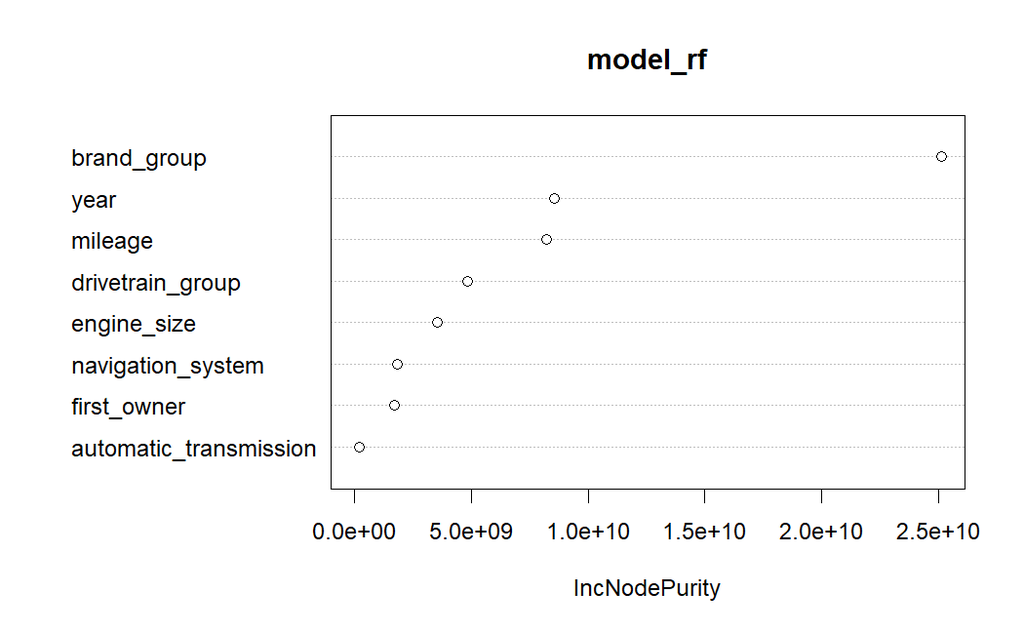

```r
# Feature importance plot for Random Forest
varImpPlot(model_rf)
```

```r
#brand_group, year and mileage have significantly higher IncNodePurity values so re the most important predictors in predicting car prices.
```

Model 2 is better than Model 1 so far.

## 3.3 Critique model using relevant diagnostics

1. Model 1 was a maximal model with no heteroscedasticity, but had a large equation, many predictors, and moderate fit statistics (RSE = 5326, R-squared = 0.82, F-statistic = 40.8).
2. Model 2 reduced the levels of categorical predictors with more than two levels, resulting in fewer predictors and better fit statistics (RSE = 3886, R-squared = 0.89, F-statistic = 343.5).
3. Model 2 outperforms Model 1 in terms of RMSE, R-squared, and MAE. Model 2 (with 8 predictors) shows lower RMSE (3961.563 vs. 6152.944), higher R-squared (0.893 vs. 0.751), and lower MAE (3277.534 vs. 4533.42) compared to Model 1 (with 11 predictors).
4. Model 1 shows: Newer cars have higher prices. Higher mileage reduces the price. Larger “engine_size” increases price. Being a first owner increases prices.
5. Potential Weakness involves
   1. Hetroscedacity presence and incomplete removal by the model.
   2. Loss of information, over-generalisation and/or biased results due to reduction of categorical variables’ levels.
   3. Model Predictions: Unequal variance across predictors affect the accuracy of prediction.
   4. Misleading Residual Analysis: Residual plots might mislead interpretations.
   5. Biased Estimates: Heteroscedasticity violates the assumption of homoscedasticity,leading to biased estimates of coefficients and their standard errors

## 3.4 Suggest and implement improvements to your model

```
  - Alternative Approach:
```

Apply log transformation to price to reduce heteroscedasticity, resulting in the lowest RSE.

1. Keep the categorical variables with more than two levels without reduction. Apply log transformation to the price to reduce heteroscedasticity, similar to Model 3.
2. Model Evaluation: Use cross-validation to evaluate the model’s predictive power. Compare the RSE, R-squared, and F-statistic values with those of Model 3.
3. Feature Importance Analysis: Conduct a feature importance analysis to understand which predictors are most important in the new model.

```r
# Reducing Hetroscedacity

# Apply transformations to response or predictor variables
mydf$log_Price <- log(mydf$price)  # Log transformation on response variable

# Re-fit the model with transformed variables
model_log <- lm(log_Price ~ year + mileage + engine_size + avg_mpg + brand_group + automatic_transmission + fuel_group + drivetrain_group + damaged + first_owner + navigation_system + bluetooth + third_row_seating + heated_seats, data = mydf)

summary(model_log)
```

```
Call:
lm(formula = log_Price ~ year + mileage + engine_size + avg_mpg +
    brand_group + automatic_transmission + fuel_group + drivetrain_group +
    damaged + first_owner + navigation_system + bluetooth + third_row_seating +
    heated_seats, data = mydf)

Residuals:
     Min       1Q   Median       3Q      Max
-0.64366 -0.10278  0.01378  0.12192  0.57919

Coefficients:
                                    Estimate Std. Error t value Pr(>|t|)
(Intercept)                       -8.622e+00  4.196e+00  -2.055   0.0406 *
year                               9.523e-03  2.092e-03   4.553 7.07e-06 ***
mileage                           -4.139e-06  4.109e-07 -10.073  < 2e-16 ***
engine_size                        5.717e-02  1.227e-02   4.658 4.38e-06 ***
avg_mpg                           -9.803e-04  2.030e-03  -0.483   0.6295
brand_groupLow_Price              -6.221e-01  4.095e-02 -15.192  < 2e-16 ***
brand_groupMid_Price              -2.191e-01  2.954e-02  -7.416 7.49e-13 ***
automatic_transmission1           -3.656e-02  4.004e-02  -0.913   0.3618
fuel_groupPetrol                  -3.164e-02  3.830e-02  -0.826   0.4093
drivetrain_groupFour-wheel Drive  -2.644e-02  2.846e-02  -0.929   0.3535
drivetrain_groupFront-wheel Drive -2.014e-01  3.325e-02  -6.058 3.23e-09 ***
damaged1                           3.720e-04  2.439e-02   0.015   0.9878
first_owner1                       4.402e-02  2.278e-02   1.932   0.0541 .
navigation_system1                 1.856e-02  2.383e-02   0.779   0.4364
bluetooth1                         8.701e-02  3.412e-02   2.550   0.0111 *
third_row_seating1                 6.592e-02  3.778e-02   1.745   0.0817 .
heated_seats1                      8.844e-03  2.196e-02   0.403   0.6874
---
Signif. codes:  0 ‘***’ 0.001 ‘**’ 0.01 ‘*’ 0.05 ‘.’ 0.1 ‘ ’ 1

Residual standard error: 0.1959 on 393 degrees of freedom
Multiple R-squared:  0.8463,    Adjusted R-squared:   0.84
F-statistic: 135.2 on 16 and 393 DF,  p-value: < 2.2e-16
```

```r
step(model_log)
```

```
Start:  AIC=-1320.16
log_Price ~ year + mileage + engine_size + avg_mpg + brand_group +
    automatic_transmission + fuel_group + drivetrain_group +
    damaged + first_owner + navigation_system + bluetooth + third_row_seating +
    heated_seats

                         Df Sum of Sq    RSS     AIC
- damaged                 1    0.0000 15.079 -1322.2
- heated_seats            1    0.0062 15.086 -1322.0
- avg_mpg                 1    0.0089 15.088 -1321.9
- navigation_system       1    0.0233 15.103 -1321.5
- fuel_group              1    0.0262 15.106 -1321.5
- automatic_transmission  1    0.0320 15.111 -1321.3
<none>                                15.079 -1320.2
- third_row_seating       1    0.1169 15.196 -1319.0
- first_owner             1    0.1432 15.223 -1318.3
- bluetooth               1    0.2496 15.329 -1315.4
- year                    1    0.7953 15.875 -1301.1
- engine_size             1    0.8324 15.912 -1300.1
- drivetrain_group        2    1.9498 17.029 -1274.3
- mileage                 1    3.8930 18.973 -1228.0
- brand_group             2    9.5439 24.623 -1123.1

Step:  AIC=-1322.16
log_Price ~ year + mileage + engine_size + avg_mpg + brand_group +
    automatic_transmission + fuel_group + drivetrain_group +
    first_owner + navigation_system + bluetooth + third_row_seating +
    heated_seats

                         Df Sum of Sq    RSS     AIC
- heated_seats            1    0.0062 15.086 -1324.0
- avg_mpg                 1    0.0090 15.088 -1323.9
- navigation_system       1    0.0233 15.103 -1323.5
- fuel_group              1    0.0263 15.106 -1323.4
- automatic_transmission  1    0.0325 15.112 -1323.3
<none>                                15.079 -1322.2
- third_row_seating       1    0.1169 15.196 -1321.0
- first_owner             1    0.1432 15.223 -1320.3
- bluetooth               1    0.2516 15.331 -1317.4
- year                    1    0.7972 15.877 -1303.0
```

[output cut: 96 more lines]

```
    data = mydf)

Coefficients:
                      (Intercept)                               year
                       -7.275e+00                          8.819e-03
                          mileage                        engine_size
                       -4.125e-06                          5.796e-02
             brand_groupLow_Price               brand_groupMid_Price
                       -6.348e-01                         -2.261e-01
 drivetrain_groupFour-wheel Drive  drivetrain_groupFront-wheel Drive
                       -3.085e-02                         -2.073e-01
                     first_owner1                         bluetooth1
                        4.096e-02                          9.754e-02
               third_row_seating1
                        6.896e-02
```

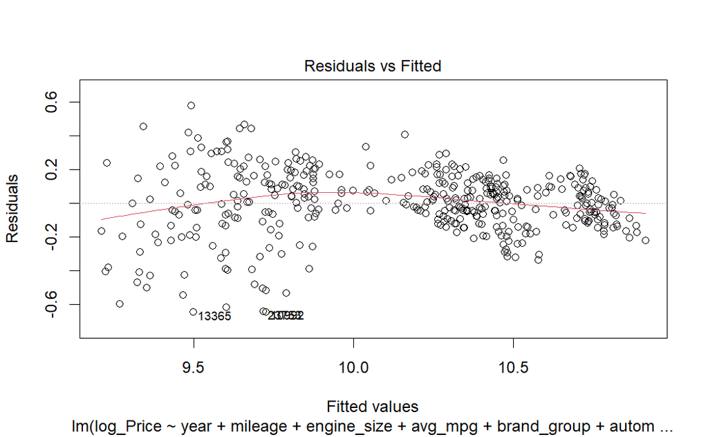

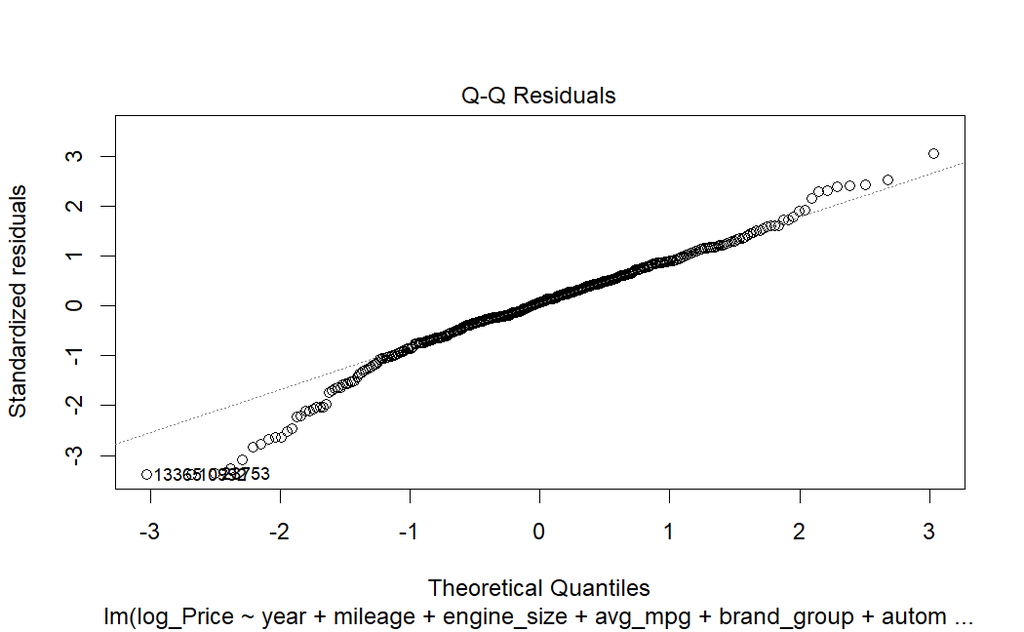

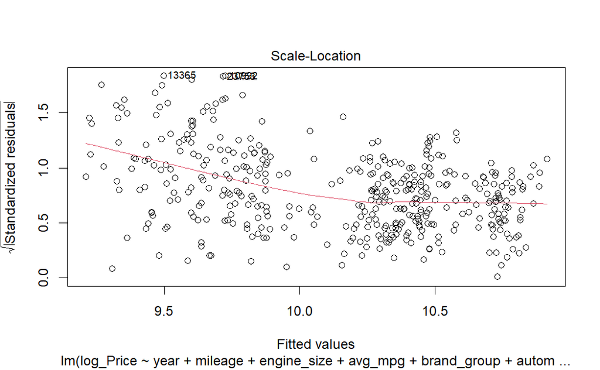

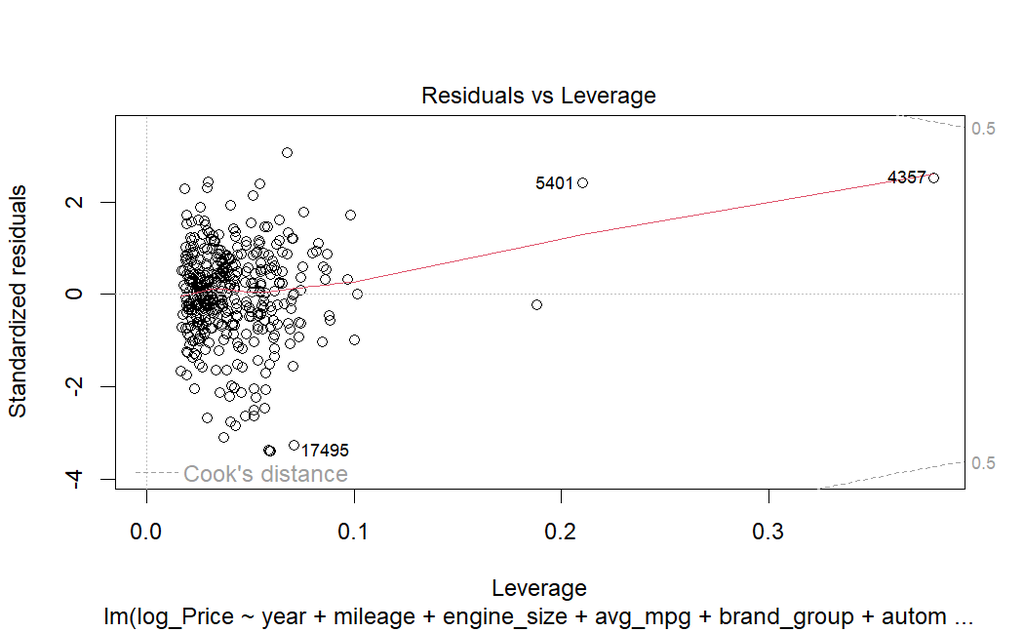

```r
plot(model_log)
```

Performing cross-validation(e.g.RMSE, MAE etc) and Random Forest

```r
# Cross-validation with caret package (example with 10-fold cross-validation)

set.seed(123)
cv_results <- train(
  log_Price ~ year + mileage + engine_size + avg_mpg + brand_group + automatic_transmission + fuel_group +   drivetrain_group + damaged + first_owner + navigation_system + bluetooth + third_row_seating + heated_seats,
  data = mydf,
  method = "lm",
  trControl = trainControl(method = "cv", number = 10)
)
print(cv_results)
```

```
Linear Regression

410 samples
 14 predictor

No pre-processing
Resampling: Cross-Validated (10 fold)
Summary of sample sizes: 367, 370, 368, 368, 370, 369, ...
Resampling results:

  RMSE       Rsquared   MAE
  0.2001141  0.8338384  0.1522402

Tuning parameter 'intercept' was held constant at a value of TRUE
```

```r
# RMSE (Root Mean Squared Error): The average error (in price) is  0.20
# R-squared: The proportion of variance in the car prices that can be explained by the model is 0.833
# MAE (Mean Absolute Error): Difference between predicted and actual prices is 0.1522

# Random Forest

model_rf <- randomForest(log_Price ~ year + mileage + engine_size + avg_mpg + brand_group + automatic_transmission + fuel_group + drivetrain_group + damaged + first_owner + navigation_system + bluetooth + third_row_seating + heated_seats, data = mydf)
print(model_rf)
```

```
Call:
 randomForest(formula = log_Price ~ year + mileage + engine_size +      avg_mpg + brand_group + automatic_transmission + fuel_group +      drivetrain_group + damaged + first_owner + navigation_system +      bluetooth + third_row_seating + heated_seats, data = mydf)
               Type of random forest: regression
                     Number of trees: 500
No. of variables tried at each split: 4

          Mean of squared residuals: 0.02762614
                    % Var explained: 88.46
```

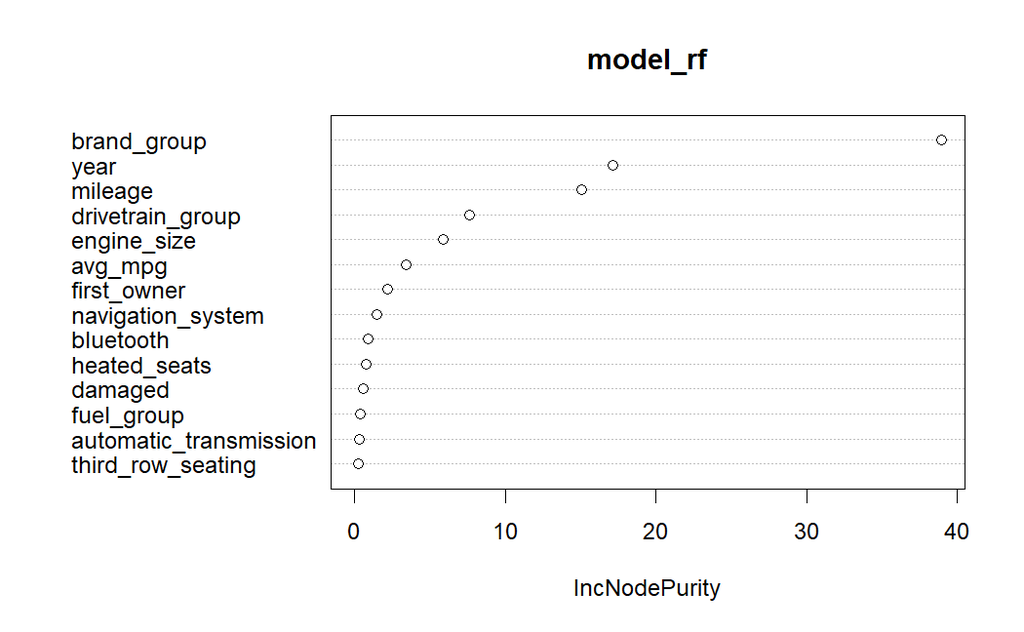

```r
# Feature importance plot for Random Forest
varImpPlot(model_rf)
```

```r
#brand_group, year and mileage have significantly higher IncNodePurity values so re the most important predictors in predicting car prices.
```

Summary of Model 3:

```r
mod <- lm(formula = log_Price ~ year + mileage + engine_size + brand_group +
    drivetrain_group + first_owner + bluetooth + third_row_seating,
    data = mydf)

summary(mod)
```

```
Call:
lm(formula = log_Price ~ year + mileage + engine_size + brand_group +
    drivetrain_group + first_owner + bluetooth + third_row_seating,
    data = mydf)

Residuals:
     Min       1Q   Median       3Q      Max
-0.62984 -0.10416  0.01315  0.12074  0.57856

Coefficients:
                                    Estimate Std. Error t value Pr(>|t|)
(Intercept)                       -7.275e+00  3.981e+00  -1.828  0.06834 .
year                               8.819e-03  1.977e-03   4.460 1.07e-05 ***
mileage                           -4.125e-06  3.993e-07 -10.332  < 2e-16 ***
engine_size                        5.796e-02  1.146e-02   5.060 6.43e-07 ***
brand_groupLow_Price              -6.348e-01  3.954e-02 -16.053  < 2e-16 ***
brand_groupMid_Price              -2.261e-01  2.885e-02  -7.838 4.20e-14 ***
drivetrain_groupFour-wheel Drive  -3.085e-02  2.777e-02  -1.111  0.26729
drivetrain_groupFront-wheel Drive -2.073e-01  3.219e-02  -6.442 3.40e-10 ***
first_owner1                       4.096e-02  2.255e-02   1.816  0.07009 .
bluetooth1                         9.754e-02  3.273e-02   2.981  0.00305 **
third_row_seating1                 6.896e-02  3.703e-02   1.862  0.06335 .
---
Signif. codes:  0 ‘***’ 0.001 ‘**’ 0.01 ‘*’ 0.05 ‘.’ 0.1 ‘ ’ 1

Residual standard error: 0.1951 on 399 degrees of freedom
Multiple R-squared:  0.8452,    Adjusted R-squared:  0.8413
F-statistic: 217.8 on 10 and 399 DF,  p-value: < 2.2e-16
```

Model Equation is:
$$\text{log_Price} = -7.275 + 0.00882 \times \text{year} - 4.125 \times
10^{-6} \times \text{mileage} + 0.05796 \times \text{engine_size} -
0.6348 \times \text{brand_groupLow_Price}
- 0.2261 \times \text{brand_groupMid_Price} - 0.03085 \times
\text{drivetrain_groupFour-wheel Drive} - 0.2073 \times
\text{drivetrain_groupFront-wheel Drive} + 0.041 \times
\text{first_owner1} + 0.09754 \times \text{bluetooth1} + 0.06896 \times
\text{third_row_seating1}$$
Regression Tree for modelling interactions:

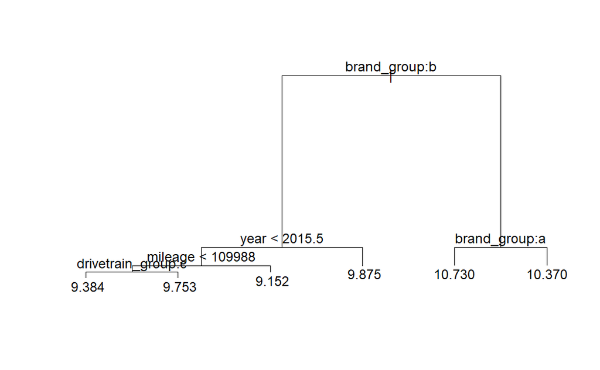

```r
mod.tree<-tree(log_Price ~ year+ mileage +engine_size +avg_mpg + brand_group +automatic_transmission +fuel_group + drivetrain_group+ damaged + first_owner + navigation_system + bluetooth + third_row_seating + heated_seats, data = mydf)
plot(mod.tree)
text(mod.tree)
```

# 4. Modelling another dependent variable

## 4.1 Model the likelihood of a car being sold by the first owner (using the first_owner variable provided).

1. Exploration & Initial Model: Explore first_owner using glm with categorical variables. Fit an initial glm model with all relevant predictors for predicting used car prices.
2. Stepwise Selection: Utilize step() to iteratively select predictors.
3. Visualizing Improvement: Create plots for stepwise selection process.
4. Check for heteroscedasticity example by Residuals vs. Fitted Values etc
5. Heteroscedasticity Reduction: If identified, consider grouped/ungrouped levels in categorical variables.
6. Model Evaluation: Cross-validate essential metrics: Accuracy, Kappa, Random Forest. Use Random Forest or Regression Tree to identify influential predictors. Evaluate model plots for assessment.

```r
# Distribution of the target variable
summary(mydf)
```

```
      brand          year         mileage        engine_size   automatic_transmission       fuel
 Hyundai : 29   Min.   :1953   Min.   :     0   Min.   :1.20   0: 33                  Diesel  :  2
 Honda   : 28   1st Qu.:2015   1st Qu.: 21328   1st Qu.:2.00   1:377                  Electric:  7
 FIAT    : 24   Median :2019   Median : 43286   Median :2.40                          GPL     :  5
 MINI    : 24   Mean   :2017   Mean   : 48382   Mean   :2.65                          Hybrid  : 13
 Audi    : 23   3rd Qu.:2021   3rd Qu.: 66593   3rd Qu.:3.30                          Petrol  :380
 Cadillac: 21   Max.   :2023   Max.   :190312   Max.   :6.40                          Unknown :  3
 (Other) :261
             drivetrain  damaged first_owner navigation_system bluetooth third_row_seating heated_seats
 2WD              :  1   0:315   0:200       0:228             0: 53     0:374             0:232
 Four-wheel Drive :199   1: 95   1:210       1:182             1:357     1: 36             1:178
 Front-wheel Drive:130
 Rear-wheel Drive : 77
 Unknown          :  3


     price          avg_mpg          brand_group           drivetrain_group  fuel_group
 Min.   : 5850   Min.   : 0.00   High_Price: 77   Other            : 81     Other : 30
 1st Qu.:18991   1st Qu.:21.50   Low_Price :168   Four-wheel Drive :199     Petrol:380
 Median :28512   Median :24.50   Mid_Price :165   Front-wheel Drive:130
 Mean   :28399   Mean   :24.72
 3rd Qu.:37564   3rd Qu.:27.00
 Max.   :54995   Max.   :52.00

   log_Price
 Min.   : 8.674
 1st Qu.: 9.852
 Median :10.258
 Mean   :10.148
 3rd Qu.:10.534
 Max.   :10.915
```

```r
str(mydf)
```

```
'data.frame':   410 obs. of  19 variables:
 $ brand                 : Factor w/ 25 levels "Alfa","Audi",..: 2 12 7 11 1 20 4 4 9 1 ...
 $ year                  : num  2022 2021 2021 2022 2019 ...
 $ mileage               : num  7232 60942 45701 2963 47587 ...
 $ engine_size           : num  2 1.6 3 3.6 2 5.6 2 3.6 1.6 2 ...
 $ automatic_transmission: Factor w/ 2 levels "0","1": 2 2 2 2 2 2 2 2 2 2 ...
 $ fuel                  : Factor w/ 6 levels "Diesel","Electric",..: 5 5 5 5 5 5 5 5 5 5 ...
 $ drivetrain            : Factor w/ 5 levels "2WD","Four-wheel Drive",..: 2 3 2 2 2 4 3 3 3 2 ...
 $ damaged               : Factor w/ 2 levels "0","1": 1 2 1 1 1 1 1 2 1 1 ...
 $ first_owner           : Factor w/ 2 levels "0","1": 2 2 2 2 2 2 2 2 1 2 ...
 $ navigation_system     : Factor w/ 2 levels "0","1": 1 1 2 1 1 2 1 2 2 1 ...
 $ bluetooth             : Factor w/ 2 levels "0","1": 2 2 2 1 2 2 2 2 2 2 ...
 $ third_row_seating     : Factor w/ 2 levels "0","1": 1 1 2 1 1 2 1 1 1 1 ...
 $ heated_seats          : Factor w/ 2 levels "0","1": 2 1 2 1 1 1 1 1 2 1 ...
 $ price                 : num  37500 15990 46290 44290 28990 ...
 $ avg_mpg               : num  32 32 21 25 25.5 15.5 7 21 23.5 28.5 ...
 $ brand_group           : Factor w/ 3 levels "High_Price","Low_Price",..: 3 2 1 1 3 2 3 3 2 3 ...
 $ drivetrain_group      : Factor w/ 3 levels "Other","Four-wheel Drive",..: 2 3 2 2 2 1 3 3 3 2 ...
 $ fuel_group            : Factor w/ 2 levels "Other","Petrol": 2 2 2 2 2 2 2 2 2 2 ...
 $ log_Price             : num  10.53 9.68 10.74 10.7 10.27 ...
```

```r
table(mydf$first_owner)
```

```
  0   1
200 210
```

```r
numerical_cols <- c("year", "mileage", "engine_size", "avg_mpg", "price")
categorical_cols <- c("brand_group", "automatic_transmission", "fuel_group", "drivetrain_group", "damaged",
                      "navigation_system", "bluetooth", "third_row_seating", "heated_seats")

for(col in numerical_cols){
  anova_result <- aov(mydf[[col]] ~ first_owner, data = mydf)
  cat("ANOVA between 'first_owner' and '", col, "':\n")
  print(summary(anova_result))
}
```

```
ANOVA between 'first_owner' and ' year ':
             Df Sum Sq Mean Sq F value   Pr(>F)
first_owner   1   1705  1705.0    47.2 2.41e-11 ***
Residuals   408  14740    36.1
---
Signif. codes:  0 ‘***’ 0.001 ‘**’ 0.01 ‘*’ 0.05 ‘.’ 0.1 ‘ ’ 1
ANOVA between 'first_owner' and ' mileage ':
             Df    Sum Sq   Mean Sq F value Pr(>F)
first_owner   1 9.479e+10 9.479e+10   101.7 <2e-16 ***
Residuals   408 3.802e+11 9.319e+08
---
Signif. codes:  0 ‘***’ 0.001 ‘**’ 0.01 ‘*’ 0.05 ‘.’ 0.1 ‘ ’ 1
ANOVA between 'first_owner' and ' engine_size ':
             Df Sum Sq Mean Sq F value Pr(>F)
first_owner   1    0.2  0.2391   0.222  0.638
Residuals   408  440.1  1.0786
ANOVA between 'first_owner' and ' avg_mpg ':
             Df Sum Sq Mean Sq F value Pr(>F)
first_owner   1      0    0.43   0.013  0.908
Residuals   408  12986   31.83
ANOVA between 'first_owner' and ' price ':
             Df    Sum Sq   Mean Sq F value Pr(>F)
first_owner   1 8.852e+09 8.852e+09   73.66 <2e-16 ***
Residuals   408 4.903e+10 1.202e+08
---
Signif. codes:  0 ‘***’ 0.001 ‘**’ 0.01 ‘*’ 0.05 ‘.’ 0.1 ‘ ’ 1
```

```r
#first_owner and avg_mpg insignificant corelation
#first_owner and engine_size insignificant corelation
```

2. Building a maximal model for first_owner using step() using original columns (without reducing categorical levels)

```r
# Fit logistic regression model
model_first_owner <- glm(first_owner ~ year + mileage + engine_size + avg_mpg + brand + automatic_transmission + fuel + drivetrain + damaged + price + navigation_system + bluetooth + third_row_seating + heated_seats, data = mydf, family = binomial)

# Summary of the model
summary(model_first_owner)
```

```
Call:
glm(formula = first_owner ~ year + mileage + engine_size + avg_mpg +
    brand + automatic_transmission + fuel + drivetrain + damaged +
    price + navigation_system + bluetooth + third_row_seating +
    heated_seats, family = binomial, data = mydf)

Coefficients:
                              Estimate Std. Error z value Pr(>|z|)
(Intercept)                 -1.883e+02  2.914e+03  -0.065  0.94847
year                         9.588e-02  5.065e-02   1.893  0.05835 .
mileage                     -2.265e-05  7.040e-06  -3.218  0.00129 **
engine_size                 -1.309e-01  2.033e-01  -0.644  0.51963
avg_mpg                     -6.941e-03  2.936e-02  -0.236  0.81309
brandAudi                   -5.486e-01  7.945e-01  -0.690  0.48988
brandBMW                     4.469e-01  1.073e+00   0.416  0.67709
brandCadillac               -2.123e-01  8.733e-01  -0.243  0.80794
brandChevrolet               3.401e-01  1.010e+00   0.337  0.73622
brandFIAT                   -1.178e+00  9.569e-01  -1.231  0.21828
brandFord                   -2.246e-02  1.074e+00  -0.021  0.98332
brandHonda                  -7.984e-02  8.017e-01  -0.100  0.92067
brandHyundai                 7.630e-01  8.294e-01   0.920  0.35758
brandJaguar                 -1.185e+00  8.866e-01  -1.336  0.18150
brandJeep                    4.735e-01  1.052e+00   0.450  0.65272
brandKia                     4.786e-01  1.042e+00   0.459  0.64591
brandLand                   -2.102e+00  1.114e+00  -1.886  0.05924 .
brandLexus                  -8.071e-01  9.207e-01  -0.877  0.38065
brandMaserati               -1.542e+00  8.834e-01  -1.746  0.08085 .
brandMazda                   4.796e-01  8.670e-01   0.553  0.58014
brandMercedes-Benz          -1.812e+00  1.163e+00  -1.557  0.11937
brandMINI                   -6.359e-01  8.510e-01  -0.747  0.45488
brandMitsubishi              1.776e+00  9.446e-01   1.880  0.06008 .
brandNissan                  6.839e-02  8.932e-01   0.077  0.93897
brandPorsche                -1.667e+00  1.287e+00  -1.295  0.19521
brandSuzuki                  7.400e-02  1.482e+00   0.050  0.96017
brandToyota                  5.979e-01  1.020e+00   0.586  0.55776
brandVolkswagen              6.254e-01  9.886e-01   0.633  0.52696
brandVolvo                   6.436e-01  1.243e+00   0.518  0.60445
automatic_transmission1      1.487e+00  6.316e-01   2.355  0.01853 *
fuelElectric                 1.472e+01  1.650e+03   0.009  0.99288
fuelGPL                      7.998e-01  1.891e+03   0.000  0.99966
```

[output cut: 8 more lines]

```
price                        5.454e-05  2.654e-05   2.055  0.03988 *
navigation_system1           1.536e-01  3.752e-01   0.409  0.68219
bluetooth1                  -9.633e-01  5.918e-01  -1.628  0.10355
third_row_seating1           7.971e-01  5.824e-01   1.369  0.17113
heated_seats1               -1.067e-02  3.093e-01  -0.035  0.97248
---
Signif. codes:  0 ‘***’ 0.001 ‘**’ 0.01 ‘*’ 0.05 ‘.’ 0.1 ‘ ’ 1

(Dispersion parameter for binomial family taken to be 1)

    Null deviance: 568.14  on 409  degrees of freedom
Residual deviance: 373.07  on 365  degrees of freedom
AIC: 463.07

Number of Fisher Scoring iterations: 15
```

```r
step(model_first_owner)
```

```
Start:  AIC=463.07
first_owner ~ year + mileage + engine_size + avg_mpg + brand +
    automatic_transmission + fuel + drivetrain + damaged + price +
    navigation_system + bluetooth + third_row_seating + heated_seats

                         Df Deviance    AIC
- brand                  24   407.65 449.65
- fuel                    5   377.28 457.28
- heated_seats            1   373.07 461.07
- damaged                 1   373.08 461.08
- avg_mpg                 1   373.12 461.12
- navigation_system       1   373.24 461.24
- drivetrain              4   379.47 461.47
- engine_size             1   373.49 461.49
- third_row_seating       1   375.04 463.04
<none>                        373.07 463.07
- bluetooth               1   375.84 463.84
- year                    1   377.12 465.12
- price                   1   377.35 465.35
- automatic_transmission  1   379.27 467.27
- mileage                 1   384.06 472.06

Step:  AIC=449.65
first_owner ~ year + mileage + engine_size + avg_mpg + automatic_transmission +
    fuel + drivetrain + damaged + price + navigation_system +
    bluetooth + third_row_seating + heated_seats

                         Df Deviance    AIC
- fuel                    5   413.75 445.75
- heated_seats            1   407.65 447.65
- avg_mpg                 1   407.66 447.66
- navigation_system       1   407.77 447.77
- damaged                 1   407.79 447.79
- engine_size             1   407.94 447.94
- price                   1   408.14 448.14
<none>                        407.65 449.65
- automatic_transmission  1   412.85 452.85
- third_row_seating       1   413.38 453.38
- bluetooth               1   417.22 457.22
- drivetrain              4   426.41 460.41
```

[output cut: 119 more lines]

```
    data = mydf)

Coefficients:
                (Intercept)                         year                      mileage
                 -4.107e+02                    2.165e-01                   -2.678e-05
    automatic_transmission1   drivetrainFour-wheel Drive  drivetrainFront-wheel Drive
                  1.246e+00                   -2.479e+01                   -2.445e+01
 drivetrainRear-wheel Drive            drivetrainUnknown                   bluetooth1
                 -2.487e+01                   -1.915e+01                   -1.493e+00
         third_row_seating1
                  1.306e+00

Degrees of Freedom: 409 Total (i.e. Null);  400 Residual
Null Deviance:      568.1
Residual Deviance: 415.3    AIC: 435.3
```